# EDA: Oxidative Stress, Inflammation, and Glucocorticoid Stress

Daniel J. Naumenko

2022-09-14

### Project Description

This report is part of a straightforward project intended to determine whether immune and stress responses cause/result in/associate with oxidative stress in a wild orangutan population. Some or all of these findings may be merged with the tuanan_dietary_restriction_oxidative_stress_inflammation_cortisol project focusing on DR. However, I want to work out this biomarker-only part first, and then relate them to diet, and see if the two stories should be merged or if the amount of information is too substantial to put them together.

The question is meta-analyzed in birds in Costantini and Moller. I will be focusing on oxidative stress (acronym: OS) as a response, with immune responses (WBC, neopterin, cytokines) and stress responses (cortisol) as potential drivers of increased oxidative stress. As part of this, I would want to test whether there are age-sex differences in oxidative stress, and if I can, try to detect seasonal trends perhaps using the GAMM approach of polansky and robbins 2013 or by one of Gavin Simpson’s blogposts.

I may want to include the creatinine-residual data from caitlin, as there are myogenic and myoanabolic links between oxidative stress and lean muscle mass. ROS can stimulate expression and activity of skeletal muscle protein degradation pathways (muscle wasting).

Co-Authors: Erin R. Vogel, Rebecca S.A. Brittain, Tim Bransford (? cortisol), Alysse Moldawer (? cytokines), Lync Moldawer (? cytokines), Sri Suci Utami Atmoko, Caitlin S.A. O’Connell (ran a lot of neopterin).

How do orang neopterin levels compare to neopterin in other NHPs? - Probably answered in Liz’s dissertation.

### Summary of EDA Findings

Results focus on standard inclusion criteria (first morning void, stored on ice in the field, CV below 15%, and specific gravity above 1.003) and for each biomarker, outliers are removed if they are more than 3 standard deviatiosn away from the mean. Additionally, cortisol values are restricted to below 250,000.

For fitting mixed models, the following distributions were determined to be best:

- 8-OHdG - log-normal
- TAC - Gamma
- Neopterin - log-normal
- Cortisol - Gamma
- ELBM - normal

For covariation between biomarkers and age sex class, truncated classes were chosen. All infants and juveniles were grouped together, all adult females were grouped, and adult males were separated into flanged and unflanged.

- No apparent differences in 8-OHdG between age sex classes.
- No apparent differences in TAC between age sex classes.
- Some small differences in neopterin between age sex classes. Flanged Males exhibit higher inflammation.
- Seems flanged males might have higher cortisol levels but needs more exploration.

### Data Details

- dimensions
- for all urine samples
  - Number of samples per orangutan
  - number of samples per field worker
  - number of samples per fai tercile
  - number of samples per year
- biomarker data inclusion criteria
  - start with total number of samples with each measurement
  - remove poor CVs
  - remove low specific gravity
  - maybe remove 1.5 times IQR outliers, but definitely box plot before this step
  - non-first morning voids
  - contaminated with fecal matter
  - status not “ok”
- - Maria file from caitlin paper with individual IDs

#### To Check

- orangutan names, make sure they’re correct
- double check age-classes
- if a cytokine is marked as zero, it was below the limit of detection
  - i say give it a random non-zero number that is within the LOD range

Table 1a: All assayed samples without any removed and no specific gravity correction applied

| biomarker | non_na | minimum | maximum |
| --- | --- | --- | --- |
| 8-OHdG | 742 | 0.102 | 255.544 |
| Cortisol | 995 | 152.948 | 4405531.000 |
| G-CSF | 460 | 0.000 | 12864.000 |
| IL-10 | 457 | 0.000 | 5383.000 |
| IL-1Ra | 452 | 0.000 | 507.750 |
| IL-8/CXCL-8 | 459 | 0.000 | 2751.000 |
| MCP-1 | 461 | 0.000 | 919.540 |
| Neopterin | 1165 | 1.560 | 14243.201 |
| TNF_a | 461 | 0.000 | 919.540 |
| Total Antioxidant Capacity | 554 | 0.000 | 36.538 |

I still need to do something with the zero values for the cytokines, as they’re not really zero.

#### How many biomarker values does each individual orangutan have?

I need to double check that the values in the database under Orangutan_ID are indeed correct. Maria sent an excel file with a list of follow and sample numbers and the correct names and age_sex classes. I should merge this in and use those instead of any values in the urine database because I am not sure they’ve been QC’d.

This table has been arranged by number of 8-OHdG samples in descending order. Total biomarker values indicates the sum of all assayed samples. I also only used samples that satisfied primary inclusion criteria: kept in thermos in field, SG not dilute, a first morning void, and the CV for the given assay sample was below 15%.

| Orangutan_ID | 8-OHdG | Cortisol | G-CSF | IL-10 | IL-1Ra | IL-8/CXCL-8 | MCP-1 | Neopterin | TNF_a | Total Antioxidant Capacity | total_biomarker_values |
| --- | --- | --- | --- | --- | --- | --- | --- | --- | --- | --- | --- |
| Mindy | 64 | 56 | 15 | 14 | 15 | 17 | 16 | 62 | 19 | 49 | 327 |
| Milo | 49 | 37 | 11 | 10 | 9 | 10 | 8 | 60 | 10 | 43 | 247 |
| Juni | 44 | 48 | 18 | 16 | 14 | 18 | 15 | 55 | 18 | 24 | 270 |
| Dayak | 35 | 25 | 5 | 4 | 4 | 6 | 4 | 32 | 6 | 28 | 149 |
| Kerry | 35 | 23 | 8 | 9 | 9 | 10 | 8 | 42 | 11 | 34 | 189 |
| Kondor | 25 | 26 | 2 | 3 | 2 | 2 | 2 | 30 | 3 | 19 | 114 |
| Niko | 25 | 29 | 6 | 6 | 5 | 4 | 4 | 31 | 5 | 18 | 133 |
| Tomi | 25 | 25 | 5 | 5 | 5 | 5 | 3 | 28 | 6 | 19 | 126 |
| Jinak | 24 | 31 | 12 | 11 | 10 | 11 | 11 | 23 | 12 | 16 | 161 |
| Inul | 22 | 20 | 6 | 5 | 5 | 6 | 6 | 21 | 6 | 13 | 110 |
| Wodan | 21 | 25 | 8 | 7 | 7 | 10 | 8 | 29 | 11 | 11 | 137 |
| Mawas | 19 | 12 | 0 | 1 | 2 | 2 | 2 | 29 | 2 | 20 | 89 |
| Teju | 13 | 9 | 0 | 0 | 1 | 0 | 1 | 11 | 1 | 10 | 46 |
| Dado | 12 | 0 | 0 | 0 | 0 | 0 | 0 | 5 | 0 | 12 | 29 |
| Desy | 12 | 5 | 4 | 4 | 4 | 4 | 4 | 16 | 4 | 8 | 65 |
| Henk | 12 | 15 | 8 | 8 | 10 | 10 | 10 | 16 | 12 | 3 | 104 |
| Otto | 12 | 15 | 4 | 4 | 5 | 5 | 5 | 14 | 4 | 6 | 74 |
| Sidony | 12 | 10 | 13 | 13 | 13 | 13 | 13 | 15 | 12 | 0 | 114 |
| Ekko | 11 | 6 | 1 | 1 | 1 | 1 | 1 | 17 | 1 | 11 | 51 |
| Gismo | 11 | 5 | 1 | 1 | 1 | 1 | 1 | 17 | 1 | 11 | 50 |
| Helium | 10 | 10 | 5 | 5 | 5 | 5 | 5 | 13 | 5 | 2 | 65 |
| Sugus | 9 | 8 | 0 | 1 | 1 | 1 | 1 | 13 | 1 | 9 | 44 |
| Ted | 9 | 7 | 0 | 0 | 0 | 0 | 0 | 10 | 0 | 9 | 35 |
| Jip | 8 | 7 | 3 | 3 | 2 | 3 | 3 | 8 | 3 | 6 | 46 |
| Cinta | 7 | 7 | 0 | 0 | 0 | 0 | 0 | 7 | 0 | 7 | 28 |
| Ipsy | 6 | 6 | 1 | 1 | 1 | 1 | 1 | 9 | 1 | 5 | 32 |
| Pinky | 6 | 12 | 0 | 0 | 0 | 0 | 0 | 16 | 0 | 6 | 40 |
| Unknown unflanged male | 6 | 3 | 1 | 1 | 1 | 1 | 1 | 5 | 1 | 5 | 25 |
| Bobo | 5 | 6 | 0 | 1 | 1 | 1 | 1 | 4 | 1 | 1 | 21 |
| Tina | 5 | 7 | 0 | 0 | 0 | 0 | 0 | 10 | 0 | 5 | 27 |
| Vini | 5 | 0 | 0 | 0 | 0 | 0 | 0 | 4 | 0 | 5 | 14 |
| Katmandun | 4 | 4 | 3 | 3 | 4 | 3 | 3 | 2 | 4 | 2 | 32 |
| Sony | 4 | 0 | 1 | 2 | 2 | 3 | 2 | 3 | 2 | 2 | 21 |
| Streisel | 4 | 4 | 1 | 0 | 1 | 1 | 1 | 4 | 1 | 3 | 20 |
| Tarzan | 4 | 5 | 3 | 3 | 3 | 3 | 2 | 5 | 3 | 0 | 31 |
| Charlie | 3 | 2 | 0 | 0 | 0 | 0 | 0 | 3 | 0 | 3 | 11 |
| Kino | 3 | 3 | 1 | 1 | 1 | 1 | 1 | 3 | 2 | 3 | 19 |
| Chaz | 2 | 3 | 4 | 4 | 4 | 4 | 4 | 2 | 4 | 0 | 31 |
| Kiki | 2 | 2 | 0 | 0 | 0 | 0 | 0 | 3 | 0 | 2 | 9 |
| Max | 2 | 0 | 0 | 0 | 0 | 0 | 0 | 4 | 0 | 2 | 8 |
| Unknown flanged male | 2 | 0 | 0 | 0 | 0 | 0 | 0 | 6 | 0 | 2 | 10 |
| Whisky | 2 | 0 | 0 | 0 | 0 | 0 | 0 | 2 | 0 | 3 | 7 |
| Arthur | 1 | 1 | 0 | 0 | 0 | 0 | 0 | 4 | 0 | 1 | 7 |
| Dolay | 1 | 1 | 1 | 1 | 1 | 1 | 1 | 1 | 1 | 1 | 10 |
| Fugit | 1 | 4 | 0 | 0 | 0 | 0 | 0 | 5 | 0 | 0 | 10 |
| Guapo | 1 | 1 | 0 | 0 | 0 | 0 | 0 | 1 | 0 | 0 | 3 |
| Merkur | 1 | 0 | 0 | 0 | 0 | 0 | 0 | 1 | 0 | 1 | 3 |
| MindyMawas | 1 | 1 | 1 | 1 | 1 | 1 | 1 | 0 | 1 | 0 | 8 |
| Momo | 1 | 2 | 0 | 0 | 0 | 0 | 0 | 1 | 0 | 1 | 5 |
| Preman flanged | 1 | 0 | 0 | 0 | 0 | 0 | 0 | 0 | 0 | 1 | 2 |
| Tom | 1 | 1 | 0 | 0 | 0 | 0 | 0 | 1 | 0 | 1 | 4 |
| Tuk-Tuk | 1 | 1 | 0 | 0 | 0 | 0 | 0 | 1 | 0 | 1 | 4 |
| Unknown adolescent female | 1 | 0 | 0 | 0 | 0 | 0 | 0 | 1 | 0 | 1 | 3 |
| Wilma | 1 | 1 | 0 | 0 | 0 | 0 | 0 | 1 | 0 | 0 | 3 |
| Zola | 1 | 1 | 0 | 0 | 0 | 0 | 0 | 1 | 0 | 0 | 3 |
| Anton | 0 | 0 | 0 | 0 | 0 | 0 | 0 | 2 | 0 | 0 | 2 |
| Bella | 0 | 3 | 0 | 0 | 0 | 0 | 0 | 4 | 0 | 1 | 8 |
| Cikipos | 0 | 0 | 0 | 0 | 0 | 0 | 0 | 2 | 0 | 0 | 2 |
| Danum | 0 | 1 | 0 | 0 | 0 | 0 | 0 | 2 | 0 | 0 | 3 |
| HS150 | 0 | 0 | 0 | 0 | 0 | 0 | 0 | 3 | 0 | 0 | 3 |
| Isidor | 0 | 4 | 0 | 0 | 0 | 0 | 0 | 4 | 0 | 0 | 8 |
| Jane | 0 | 0 | 0 | 0 | 0 | 0 | 0 | 1 | 0 | 0 | 1 |
| Molong | 0 | 0 | 0 | 0 | 0 | 0 | 0 | 1 | 0 | 0 | 1 |
| Opa | 0 | 0 | 0 | 0 | 0 | 0 | 0 | 1 | 0 | 0 | 1 |
| Orchid | 0 | 1 | 0 | 0 | 0 | 0 | 0 | 1 | 0 | 0 | 2 |
| Petzy | 0 | 1 | 0 | 0 | 0 | 0 | 0 | 5 | 0 | 0 | 6 |
| Preman | 0 | 0 | 0 | 0 | 0 | 0 | 0 | 3 | 0 | 0 | 3 |
| Rex | 0 | 1 | 0 | 0 | 0 | 0 | 0 | 0 | 0 | 0 | 1 |
| Rudolf | 0 | 0 | 0 | 0 | 0 | 0 | 0 | 1 | 0 | 0 | 1 |
| Talia | 0 | 0 | 0 | 0 | 0 | 0 | 0 | 1 | 0 | 0 | 1 |
| Tuko | 0 | 0 | 0 | 0 | 0 | 0 | 0 | 5 | 0 | 0 | 5 |
| unknown indiv | 0 | 0 | 0 | 0 | 0 | 0 | 0 | 2 | 0 | 0 | 2 |
| unknown individual | 0 | 0 | 0 | 0 | 0 | 0 | 0 | 5 | 0 | 0 | 5 |

#### How many assayed samples of each biomarker meet each inclusion criterion?

I want to look at each of my inclusion criterion to determine whether any lead to significant loss of sample numbers or change balance fo the data, ultimately reducing power. When I know that a given exclusion criterion reduces power, I can make a judgement call as to what to do.

The inclusion criteria are as follows:

1. Sample is not dilute (specific gravity > 1.003)
2. Sample assay was precise (CV is equal to or below 15%)
3. Sample is from a first morning void
4. Assay was determined to have run appropriately (Sample assay status is OK, not set to ‘rerun’)

Table 1d: The number of assayed samples by biomarker that meet each inclusion criterion

| Biomarker | # of Total Assayed Samples | SG > 1.003 | Stored in Thermos | First Morning Voids |
| --- | --- | --- | --- | --- |
| 8-OHdG | 742 | 740 (99.73%) | 715 (96.36%) | 649 (87.47%) |
| Cortisol | 995 | 932 (93.67%) | 806 (81.01%) | 685 (68.84%) |
| G-CSF | 460 | 384 (83.48%) | 291 (63.26%) | 276 (60%) |
| IL-10 | 457 | 384 (84.03%) | 287 (62.8%) | 273 (59.74%) |
| IL-1Ra | 452 | 376 (83.19%) | 281 (62.17%) | 266 (58.85%) |
| IL-8/CXCL-8 | 459 | 383 (83.44%) | 289 (62.96%) | 273 (59.48%) |
| MCP-1 | 461 | 385 (83.51%) | 290 (62.91%) | 275 (59.65%) |
| Neopterin | 1165 | 1153 (98.97%) | 1043 (89.53%) | 846 (72.62%) |
| TNF_a | 461 | 386 (83.73%) | 291 (63.12%) | 275 (59.65%) |
| Total Antioxidant Capacity | 554 | 552 (99.64%) | 537 (96.93%) | 460 (83.03%) |

Ok, I will calculate percentages for each of these variables, surround the percentages in parentheses and add a percent sign, then merge the pairs of columns together in the final product. Should be able to use column_spec to add the parentheses and percentages.

After filtering out samples that were not stored in a cold thermos in the field, were not first morning voids, were too dilute, and had poor CVs, the following number of samples remained for each biomarker.

604, 446, 750, 543, 152, 149, 150, 164, 149, 174

#### How many samples have a status of “ok”?

For this one I need to make sure all records have a value here. Otherwise some NAs may get removed. I have not yet created this table.

### Variation

#### General Notes:

I am not yet sure how I want to deal with outliers. Many papers use the 1.5 * IQR method; this is reasonable. The outliers themselves should be investigated to see if I can determine why they are outliers. If there is an error, I can remove them. If they are part of natural variation, I may keep or remove them. If they are removed but seem to be accurate values, I may want to provide supplementary information on the samples in a table providing any relevant information on them.

#### 8-OHdG Variation

There appears to be a few pretty large outliers in the >90 range. A natural log transformation creates a vaguely normal distribution with some pretty long tails on either end and the potential for a little bimodality around ln2.7. The skewness of the SG-corrected 8-OHdG is 4.4674973 and kurtosis is 33.2902414

The skewness of the natural logged 8-OHdG is -0.0017255 and the kurtosis is 5.4216779. So there is a considerable reduction in both skew and kurtosis after a natural log transformation, but the distribution of these data should be explored further. Is there a reason for that near-bimodality? Age-sex class?

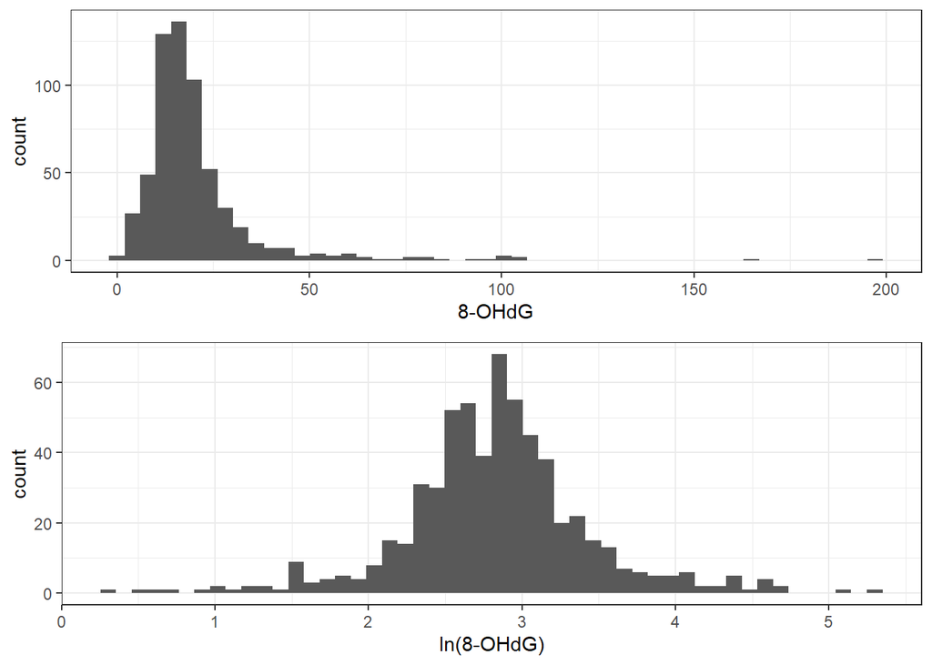

#### TAC Variation

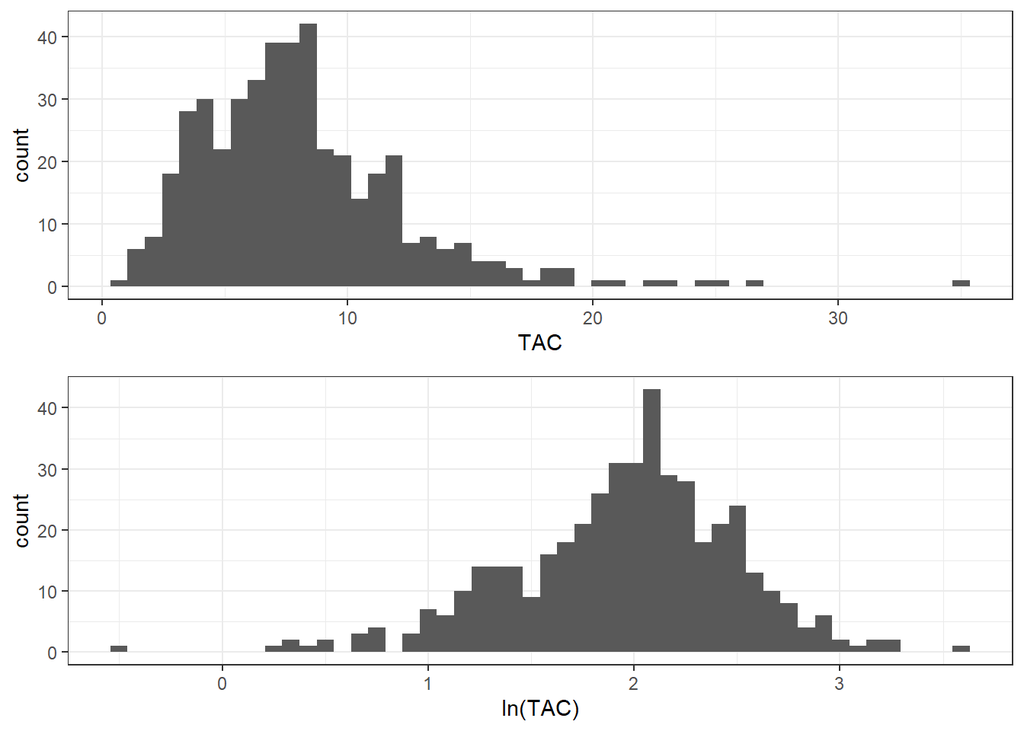

#### Neopterin Variation

Neopterin, like cortisol below, has some pretty extreme outliers, though not to the same extent as cortisol. A natural log transformation does seem to bring these values together. However, I think I’d rather model the actual data using GAMMs as those values are much more interpretable than trying to understand the logged effects of biomarkers on each other.

[figure not shown]

#### Cortisol Variation

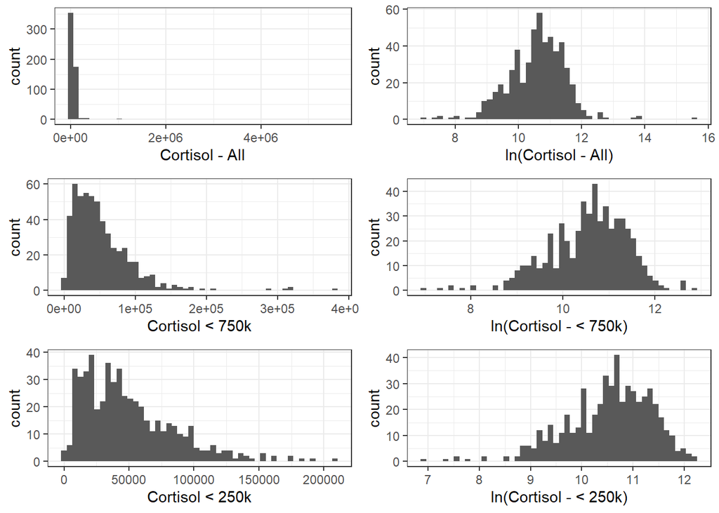

Table: Skewness and Kurtosis of cortisol at different levels of outlier removal; only samples that meet inclusion criteria used

|  | Skewness | Kurtosis |
| --- | --- | --- |
| All cortisol values | 19.902720 | 432.612382 |
| Cortisol < 750k | 2.758784 | 16.210378 |
| Cortisol < 250k | 1.205298 | 4.656539 |

There is a pretty dramatic reduction in kurtosis when the most extreme outliers are removed. The reasoning for these outliers, be they error or some latent features, should be explored. In-depth exploration is probably beyond the scope of this paper; some decision must be made for which cortisol values to include and this decision must be justifiable.

#### ELBM Distribution

I think I will keep in the outliers for now, and then see what to do about them later. *Note: as I was plotting covariation below, I routinely removed the ELBM outlier above 2*

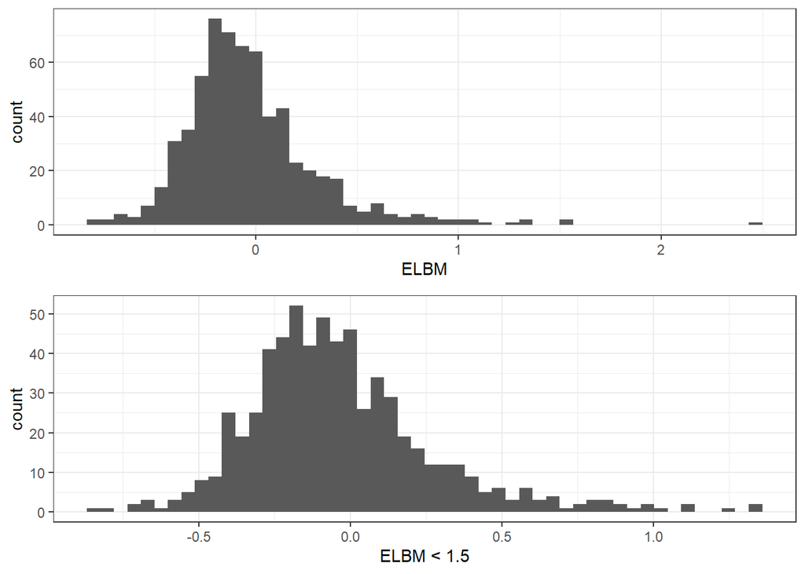

#### General Notes on Biomarker Distribution

There is some pretty heavy right tails in these data, regardless of how many outliers are removed. Special attention will need to be paid to these outliers given their sheer scale.

There is an outlier-robust GAM fitting package (rgam) that may be of use. It uses a backfitting algorithm with weights derived from robust quasi-likelihood equations. Original publication: Azadeh, A. and Salibian-Barrera, M. (2011). *An outlier-robust fit for Generalized Additive Models with applications to disease outbreak detection.*

### Outlier Analysis

Before proceeding beyond my analysis of variation of each of the biomarkers, I need to better understand what data points are outliers, why they are so different from the rest of the data, and then decide how to handle them. There are a range of techniques I could use to detect filters: z-score and flag points beyond the -3:3 z-score range, flag points outside the 1.5 * IQR range, Expectation Maximization, Mahalanobis Distance, and DBSCAN. I will focus on the last 3 first as ML algorithms and compare their findings. I will likely stick with DBSCAN as it requires fewer assumptions, but I want to check first.

*Note: On returning to this point, I am not sure how much exploration is useful here or if avoiding it is more laziness. The ML approaches seem a bit overkill.*

I want to flag each biomarker as an outlier under each method so that I can then determine if there is anything going on about them.

I created two markers for flagging each biomarker as an outlier. The first is based on -3:3 z-score. The second arranges the values of a biomarker in ascending order and calculates the distance between successive points. My motivation was that the z-score (and IQR) method(s) seem very restrictive; several reasonable variables were cut out because the average of the biomarker was lower. The distance metric for 8-OHdG, for example, shows that the only data ponits that were very different from the values around it were the last two, which exhibited jumps of over 30 and 50, while all other distances were well below 5 or 10.

*Note: After looking at a lot of the distribution and box plots, I am going with the Z-score (aka +/- 3SD) approach to identifying and removing outliers. Only the most extreme values are removed, and this approach is rather common among published papers. Work on the distance outliers can now be found in the supplement.*

### Covariation

#### Covaration between Biomarkers Alone

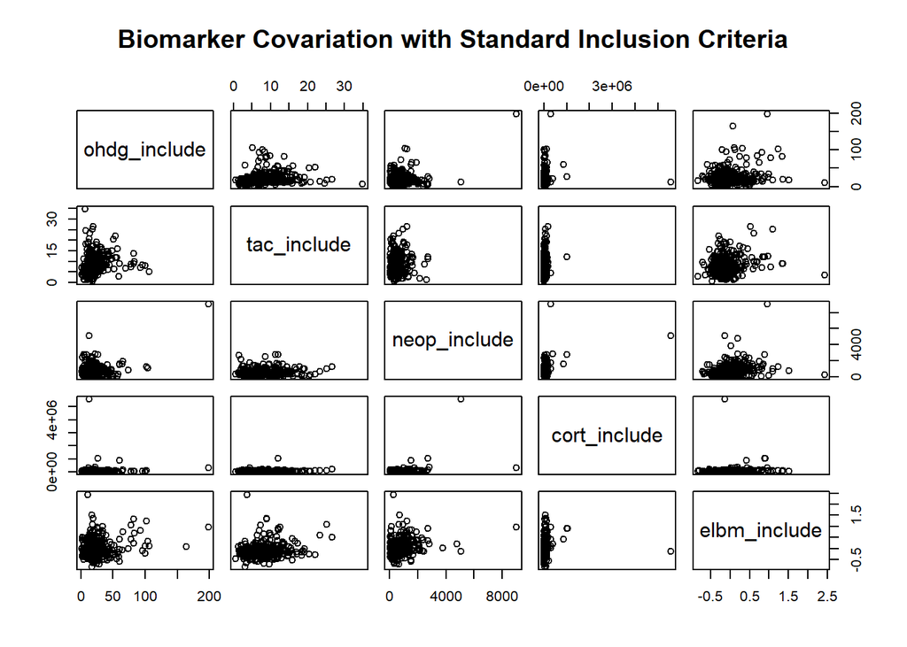

With outliers, it is difficult to determine any serious relationships.

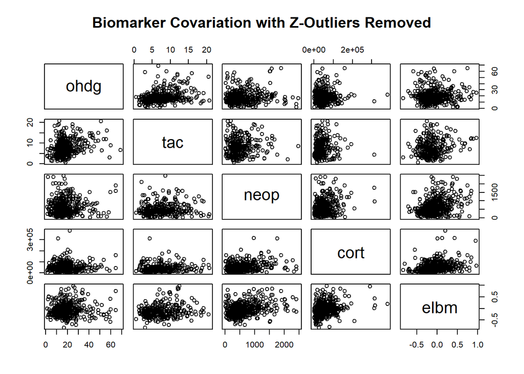

With outliers removed, several positive relationships do appear. 8-OHdG and TAC, TAC with maybe neopterin, 8-OHdG and neopterin, and ELBM with 8-OHdG, neopterin, and possibly cortisol.

#### Covariation Between Biomarkers and Truncated Age-Sex Classes

##### **8-OHdG**

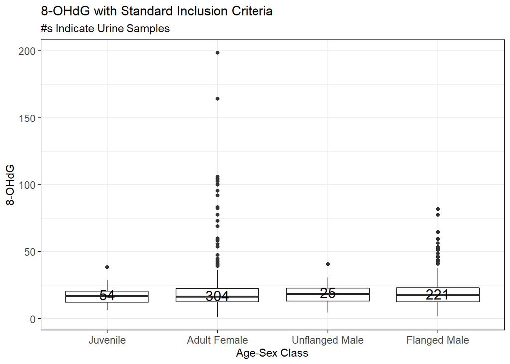

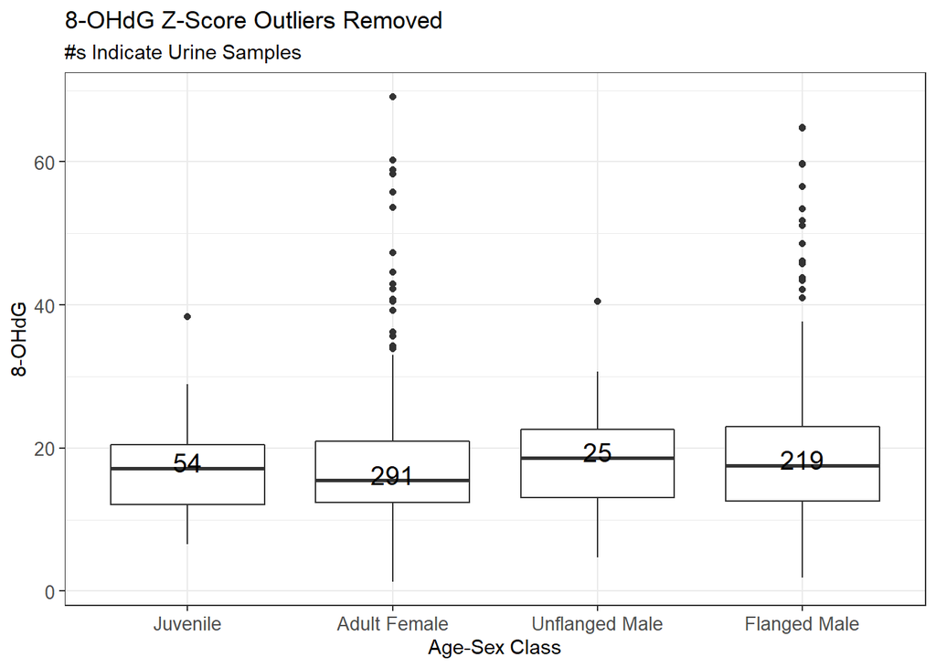

When looking at the samples with outliers removed, it almost looks like adult males may have higher 8-OHdG on average compared to females.

##### **TAC**

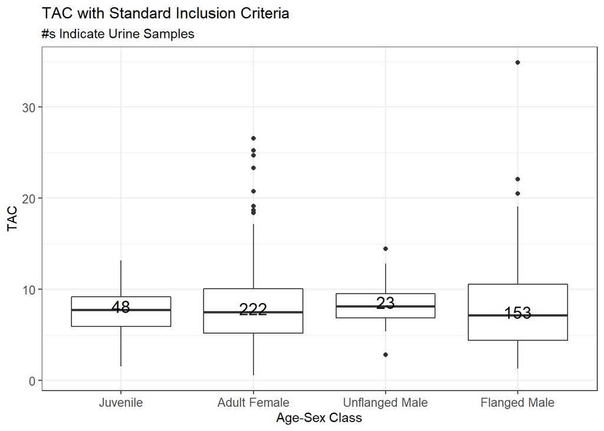

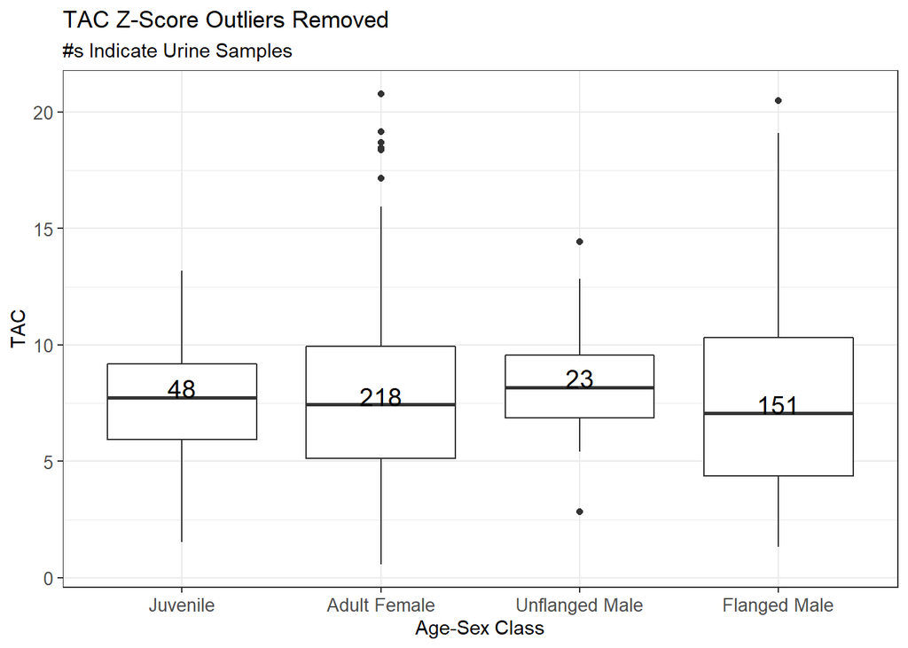

It looks like adult flanged males *might* have depressed antioxidants relative to unflanged males. However the difference in sample sizes (23 vs 151) warrants further exploration before any definitive conclusion is drawn. Some latent factor might drive this difference, especially given the range of unflanged male values falls entirely within that of the adult flanged males. Otherwise all groups seem to have a similar median and IQR.

##### **Neopterin**

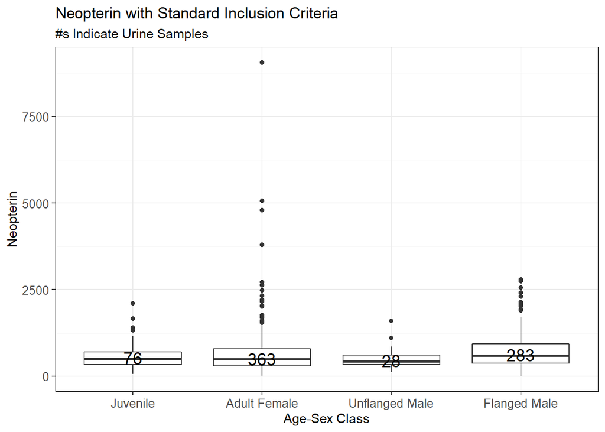

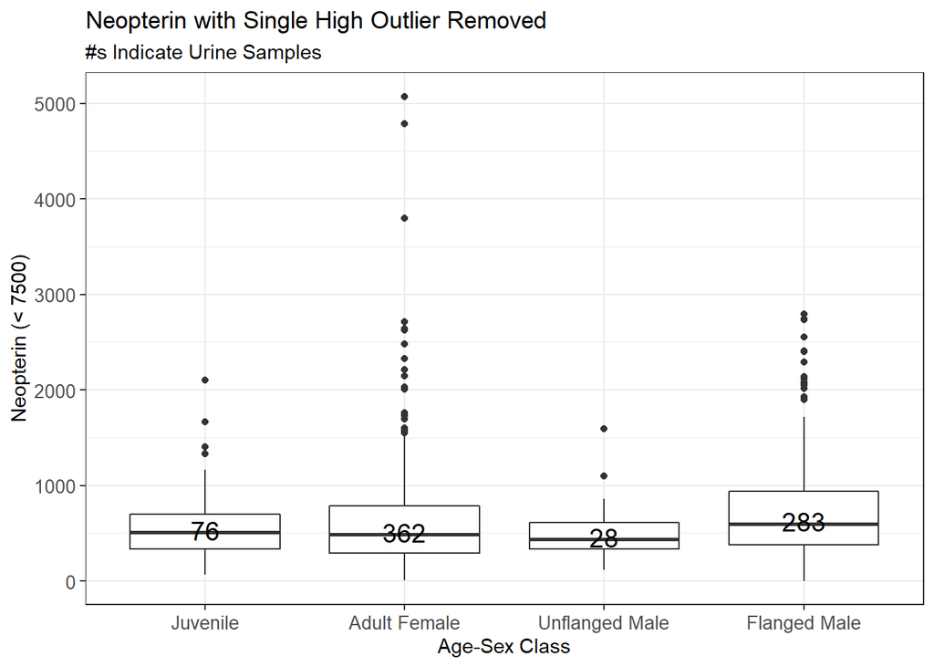

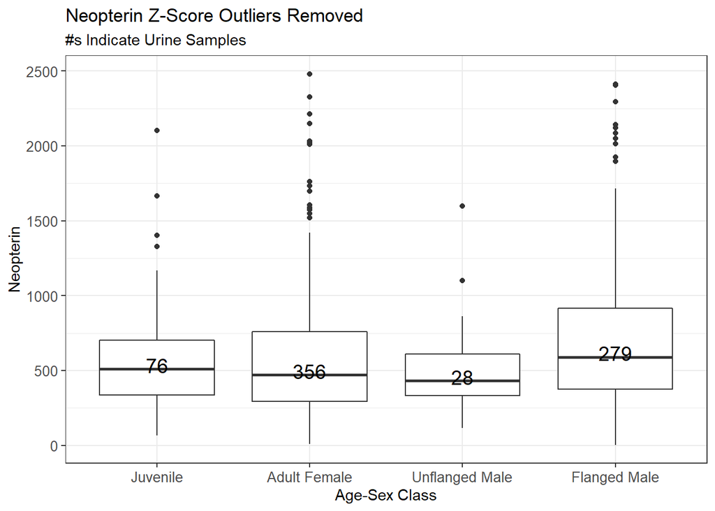

Looks like adult flanged males are dealing with greater inflammation on average when compared to adult females or adult unflanged males. This would probably fit with the idea that flanging is a costly process and the allocation of limited resources to growth and maintenance during adulthood pulls from the energy necessary to handle infections. Or perhaps something about the behavior of flanged males makes them more susceptible to infection. It is possible that behavioral differences might drive this pattern; possible explanations include flanged males 1) interact with other orangutans more frequently than unflanged males and adult females or 2) that they spend more time on the ground than unflanged males or adult females, then assessing the occurrence of these events with inflammation. Either of these might increase flanged male exposure to pathogens.

##### **Cortisol**

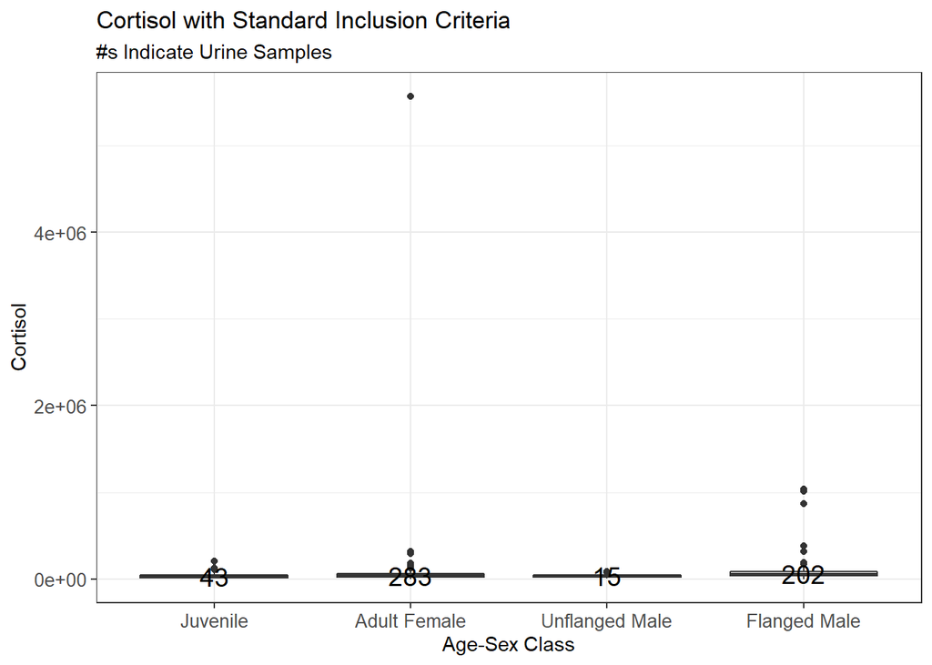

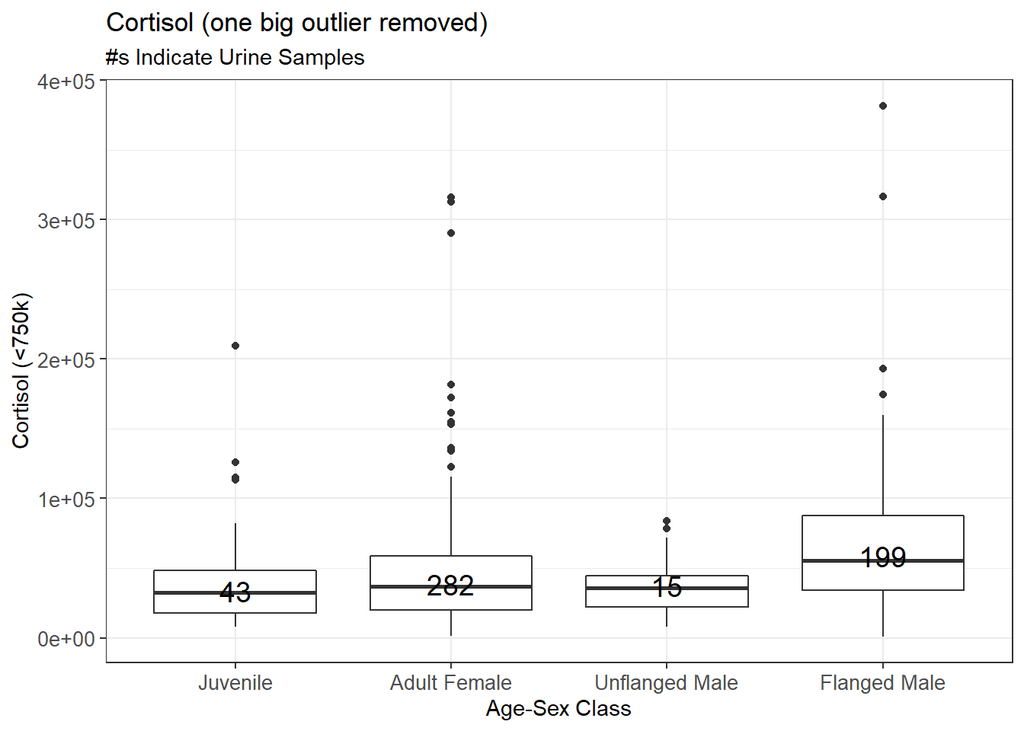

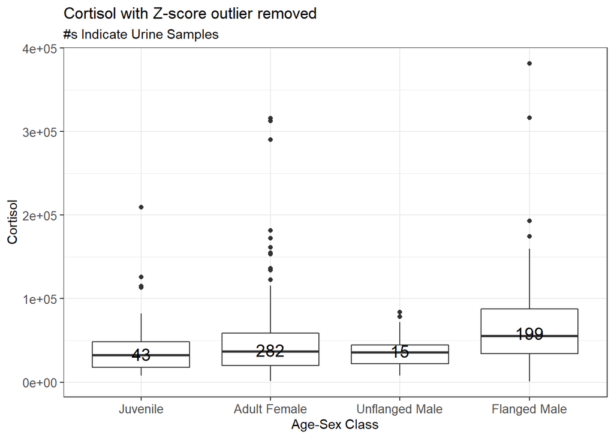

Looks like adult flanged males might be dealing with elevated cortisol relative to all other age-sex classes. Other age-classes have similar levels.

##### **ELBM**

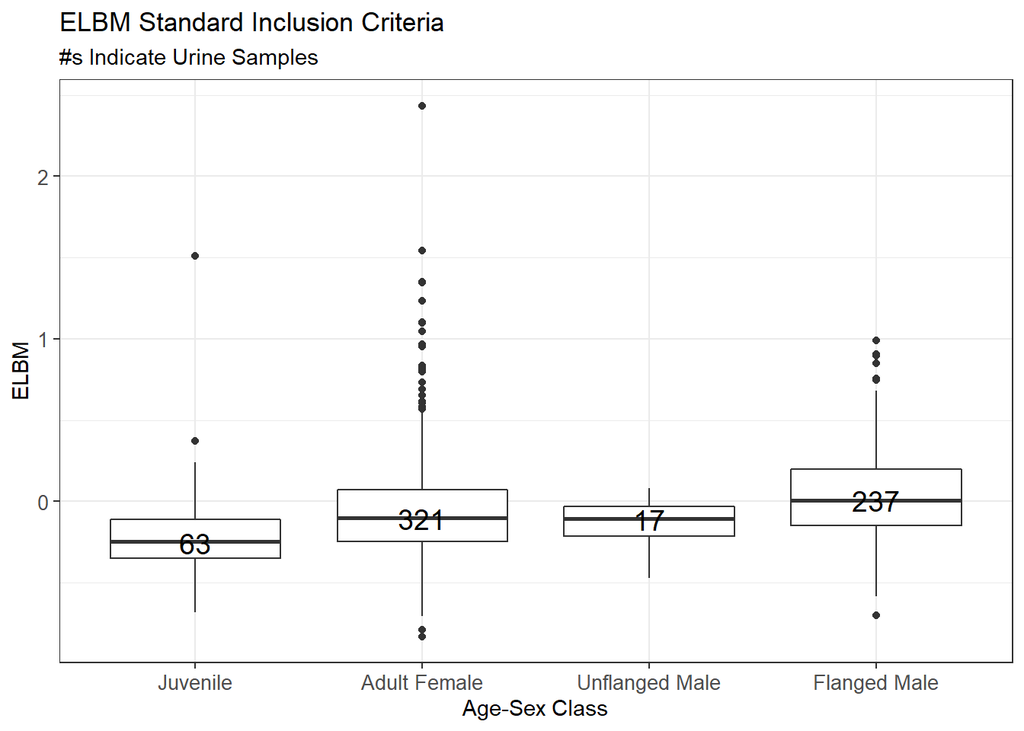

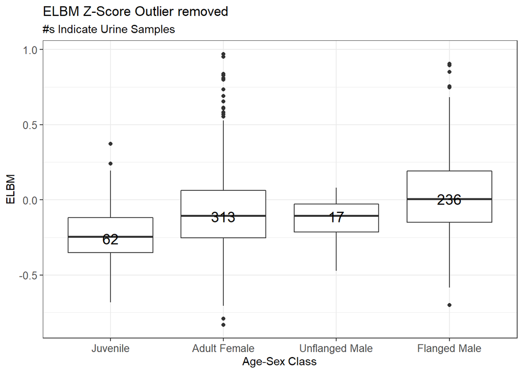

This is not new, basically partly replicated from O’Connell et al. 2021. I just wanted to visualize it within this report.

#### Formally Test Difference in Biomarkers by Age-Sex class

Note that link functions for each response variable are determined in the supplement.

I am thinking I should either combine all dependents into a single category or a young male and young female category, and then probably merge the two adult female categories together.

I am following what was done in the O’Connell et al. 2021 paper, using GAMMs to test for significant differences between age-sex classes. She used gamm4, I will use mgcv::gamm. I will need to check about the distribution family that best works for each biomarker, potentially remove individuals with low sampling, and remove or group age-sex classes with very few data points, because data are quite unbalanced. currently have a random intercept by individual, not a random slope. There are few samples so this might not be possible. Note that Caitlin is exploring Neopterin, so any results of age-class ~ neopterin are just for funsies and will not be published.

##### **8-OHdG**

```
##
##  Maximum number of PQL iterations:  20
```

```
##
## Family: gaussian
## Link function: log
##
## Formula:
## ohdg_include ~ Age_Cat_trunc
##
## Parametric coefficients:
##                             Estimate Std. Error t value Pr(>|t|)
## (Intercept)                  2.99015    0.04315  69.301   <2e-16 ***
## Age_Cat_truncJuvenile       -0.15543    0.09972  -1.559    0.120
## Age_Cat_truncAdult Female   -0.09449    0.06296  -1.501    0.134
## Age_Cat_truncUnflanged Male -0.05276    0.12473  -0.423    0.672
## ---
## Signif. codes:  0 '***' 0.001 '**' 0.01 '*' 0.05 '.' 0.1 ' ' 1
##
##
## R-sq.(adj) =  0.00393
##   Scale est. = 101.28    n = 589
```

```
## $`emmeans of Age_Cat_trunc`
##  Age_Cat_trunc  emmean    SE    df lower.CL upper.CL
##  Flanged Male     19.7 0.867  37.2     18.0     21.5
##  Juvenile         17.0 1.589  91.4     13.8     20.1
##  Adult Female     18.1 0.881  18.1     16.2     19.9
##  Unflanged Male   18.8 2.232 134.6     14.4     23.3
##
## Degrees-of-freedom method: kenward-roger
## Confidence level used: 0.95
##
## $`pairwise differences of Age_Cat_trunc`
##  1                             estimate   SE    df t.ratio p.value
##  Flanged Male - Juvenile          2.763 1.81  72.0   1.526  0.4274
##  Flanged Male - Adult Female      1.659 1.24  25.1   1.342  0.5459
##  Flanged Male - Unflanged Male    0.869 2.39 116.5   0.364  0.9834
##  Juvenile - Adult Female         -1.104 1.80  62.6  -0.613  0.9275
##  Juvenile - Unflanged Male       -1.893 2.74 117.5  -0.691  0.9003
##  Adult Female - Unflanged Male   -0.790 2.40  91.3  -0.329  0.9876
##
## Degrees-of-freedom method: kenward-roger
## P value adjustment: tukey method for comparing a family of 4 estimates
```

##### **TAC**

```
##
##  Maximum number of PQL iterations:  20
```

```
##
## Family: Gamma
## Link function: inverse
##
## Formula:
## tac_include ~ Age_Cat_trunc
##
## Parametric coefficients:
##                              Estimate Std. Error t value Pr(>|t|)
## (Intercept)                  0.129991   0.006349  20.475   <2e-16 ***
## Age_Cat_truncJuvenile        0.008728   0.012588   0.693    0.488
## Age_Cat_truncAdult Female   -0.005518   0.008903  -0.620    0.536
## Age_Cat_truncUnflanged Male -0.009398   0.014764  -0.637    0.525
## ---
## Signif. codes:  0 '***' 0.001 '**' 0.01 '*' 0.05 '.' 0.1 ' ' 1
##
##
## R-sq.(adj) =  -0.00414
##   Scale est. = 0.20618   n = 440
```

```
## [1] -1223.528
```

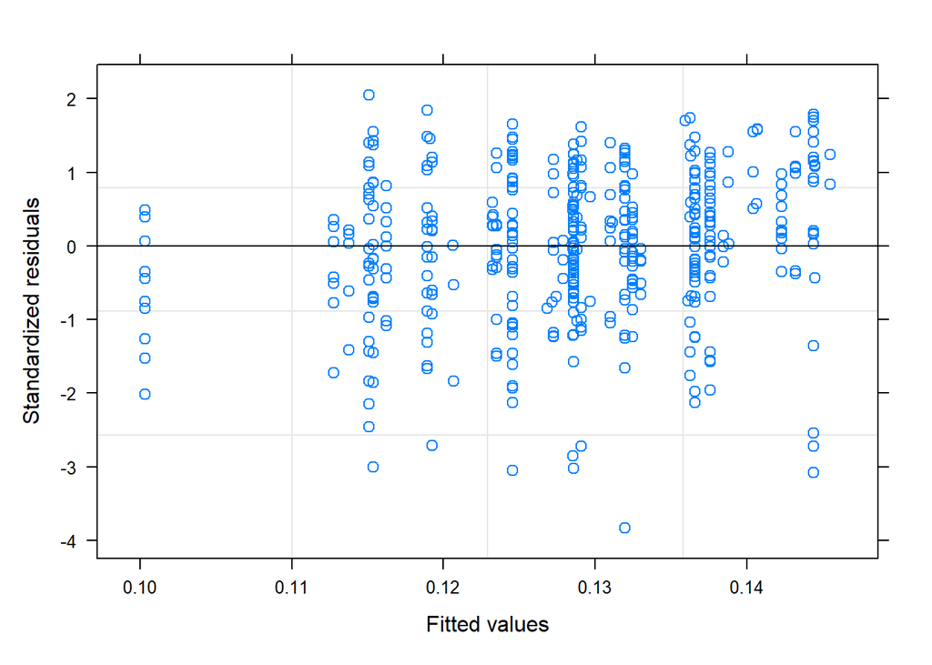

##### **Neopterin**

```
##
##  Maximum number of PQL iterations:  20
```

```
##
## Family: gaussian
## Link function: log
##
## Formula:
## neop_include ~ Age_Cat_trunc
##
## Parametric coefficients:
##                             Estimate Std. Error t value Pr(>|t|)
## (Intercept)                  6.55171    0.03672 178.426  < 2e-16 ***
## Age_Cat_truncJuvenile       -0.19085    0.09273  -2.058 0.039926 *
## Age_Cat_truncAdult Female   -0.19476    0.05393  -3.611 0.000325 ***
## Age_Cat_truncUnflanged Male -0.30050    0.16079  -1.869 0.062037 .
## ---
## Signif. codes:  0 '***' 0.001 '**' 0.01 '*' 0.05 '.' 0.1 ' ' 1
##
##
## R-sq.(adj) =  0.0169
##   Scale est. = 1.8357e+05  n = 739
```

```
## $`emmeans of Age_Cat_trunc`
##  Age_Cat_trunc  emmean   SE    df lower.CL upper.CL
##  Flanged Male      700 38.8  51.1      622      778
##  Juvenile          571 65.7 100.9      441      702
##  Adult Female      590 43.6  31.4      501      679
##  Unflanged Male    520 95.3 153.4      332      708
##
## Degrees-of-freedom method: kenward-roger
## Confidence level used: 0.95
##
## $`pairwise differences of Age_Cat_trunc`
##  1                             estimate    SE    df t.ratio p.value
##  Flanged Male - Juvenile          128.5  76.3  82.8   1.685  0.3382
##  Flanged Male - Adult Female      110.3  58.4  38.4   1.889  0.2497
##  Flanged Male - Unflanged Male    179.9 101.8 143.1   1.767  0.2936
##  Juvenile - Adult Female          -18.3  76.9  79.2  -0.237  0.9953
##  Juvenile - Unflanged Male         51.4 115.7 133.1   0.444  0.9706
##  Adult Female - Unflanged Male     69.7 104.8 106.7   0.665  0.9101
##
## Degrees-of-freedom method: kenward-roger
## P value adjustment: tukey method for comparing a family of 4 estimates
```

##### **Cortisol**

```
##
##  Maximum number of PQL iterations:  20
```

```
##
## Family: Gamma
## Link function: inverse
##
## Formula:
## cort_include ~ Age_Cat
##
## Parametric coefficients:
##               Estimate Std. Error t value Pr(>|t|)
## (Intercept)  2.759e-05  2.148e-05   1.284    0.200
## Age_CatDINC -1.026e-05  2.278e-05  -0.450    0.653
## Age_CatSII   1.960e-06  2.297e-05   0.085    0.932
## Age_CatII   -6.392e-06  2.179e-05  -0.293    0.769
## Age_CatUFM  -1.406e-06  2.220e-05  -0.063    0.950
## Age_CatAFM  -1.262e-05  2.153e-05  -0.586    0.558
## Age_CatAFnD -9.922e-06  2.190e-05  -0.453    0.651
## Age_CatAFwD -6.117e-06  2.155e-05  -0.284    0.777
##
##
## R-sq.(adj) =  0.0349
##   Scale est. = 0.57043   n = 539
```

### Additional Supplementary Information

#### Determine What Link Function is Best for GAMMs for Each Biomarker

For each of the 4 distributions (norm, lnorm, gamma, exp), four plots are produced along with parameter estimates, log likelihood, AIC, and BIC. The four plots are:

- a histogram of data (empirical) against fitted density function
- Q-Q Plot: theoretical quantiles against empirical quantiles
- empirical cumulative distribution against fitted distribution function
- P-P plot :theoretical probabilities against empirical probabilities

See the following text from the vignette for the fitdistrplus package Found at: https://cran.r-project.org/web/packages/fitdistrplus/vignettes/FAQ.html

*Goodness-of-fit tests often appear as objective tools to decide whether a fitted distribution well describes a data set. But they are not ! It would not be reasonable at all to reject a distribution just because a goodness-of-fit test rejects it (see FAQ 2.2.1). And it would not be reasonable at all any more to validate a distribution because goodness-of-fit tests do not reject it (see FAQ 2.2.2).*

*A fitted distribution should be evaluated using graphical methods (goodness-of-fit graphs automatically provided in our package by plotting the result of the fit (output of fitdist() or fitdistcens() and the complementary graphs that help to compare different fits - see ?graphcomp). We really think it is the most appropriate way to evaluate the adequacy of a fit and we are not the only ones to recommend it. You can find the same type of recommendations in reference books:*

- Probabilistic techniques in exposure assessment - a handbook dealing with variability and uncertainty in models and inputs by A.C. Cullen and H.C. Frey.
- Application of uncertainty analysis to ecological risks of pesticides by W.J. Warren-Hicks and A. Hart.
- Statistical inference by G. Casella and R.L. Berger
- Loss models: from data to decision by S.A. Klugman and H.H. Panjer and G.E. Willmot

##### **8-OHdG**

##### *Standard Inclusion Criteria*

Note: log-normal fits best but there are two substantial outliers. Plots excluded.

##### *Z-Score Outliers Removed*

Note: Based on graphs, log-normal fits best, with gamma a close second. Looking at AIC and BIC, it would seem the Gamma distribution is best. I’m not yet sure which I want to go with. log-normal’s P-P plot and Empirical/Theoretical CDFs are a tighter fit to the line their respective curves. Given what the authors say about using graphics, I am leaning choosing log-normal.

```
## Fitting of the distribution ' lnorm ' by maximum likelihood
## Parameters :
##          estimate Std. Error
## meanlog 2.7823054 0.02265424
## sdlog   0.5498031 0.01601873
## Loglikelihood:  -2122.196   AIC:  4248.391   BIC:  4257.148
## Correlation matrix:
##         meanlog sdlog
## meanlog       1     0
## sdlog         0     1
```

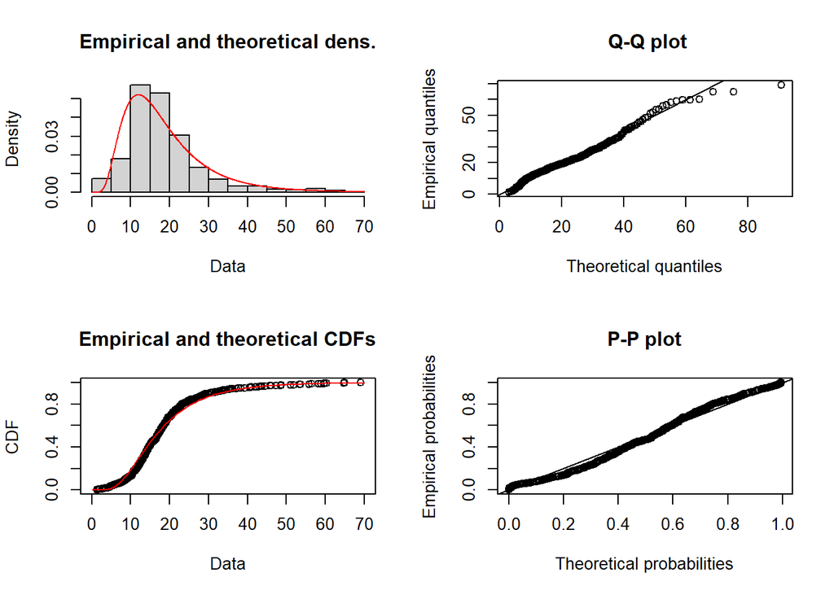

```
## Fitting of the distribution ' gamma ' by matching moments
## Parameters :
##        estimate
## shape 3.2799364
## rate  0.1765455
## Loglikelihood:  -2115.013   AIC:  4234.025   BIC:  4242.782
```

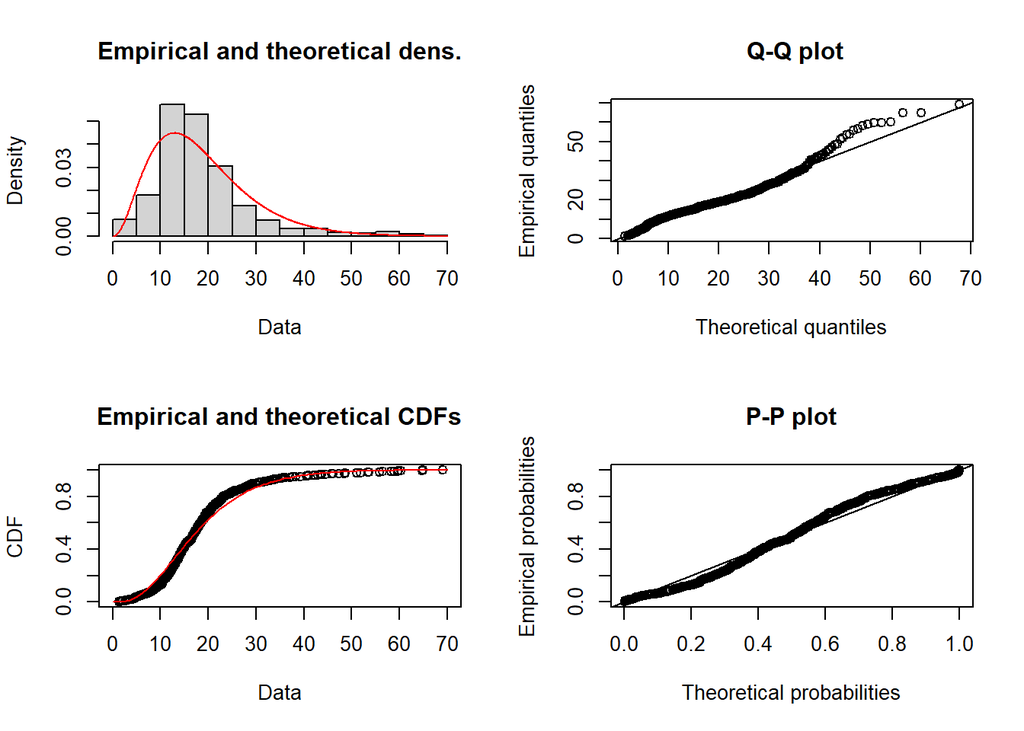

##### **TAC**

##### *Standard Inclusion Criteria*

Note: it looks like gamma fits best, with log-normal a close second. Plots excluded.

##### *Z-Score Outliers Removed*

Note: Gamma is an excellent fit

```
## Fitting of the distribution ' lnorm ' by maximum likelihood
## Parameters :
##          estimate Std. Error
## meanlog 1.9362087 0.02490563
## sdlog   0.5224249 0.01761065
## Loglikelihood:  -1190.584   AIC:  2385.168   BIC:  2393.342
## Correlation matrix:
##         meanlog sdlog
## meanlog       1     0
## sdlog         0     1
```

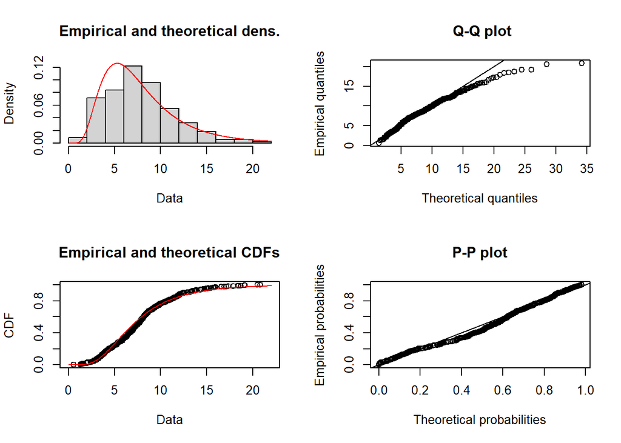

```
## Fitting of the distribution ' gamma ' by matching moments
## Parameters :
##        estimate
## shape 4.5221421
## rate  0.5775776
## Loglikelihood:  -1174.514   AIC:  2353.028   BIC:  2361.202
```

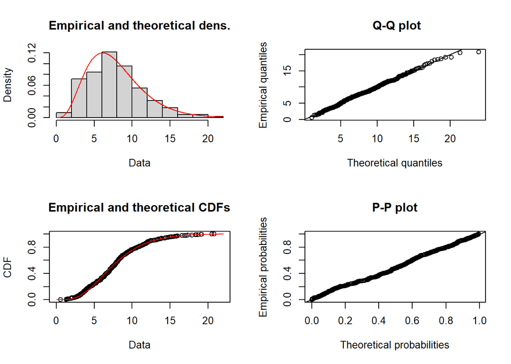

##### **Neopterin**

##### *Standard Inclusion Criteria*

Note: log-normal fits best, although there is at least one substantial outlier, with the potential for a few other smaller outliers. Plots excluded.

##### *Z-Score Outliers Removed*

Note: Gamma is best; log-normal is **not** great

```
## Fitting of the distribution ' lnorm ' by maximum likelihood
## Parameters :
##          estimate Std. Error
## meanlog 6.1828257 0.02849262
## sdlog   0.7745591 0.02014717
## Loglikelihood:  -5428.918   AIC:  10861.84   BIC:  10871.05
## Correlation matrix:
##         meanlog sdlog
## meanlog       1     0
## sdlog         0     1
```

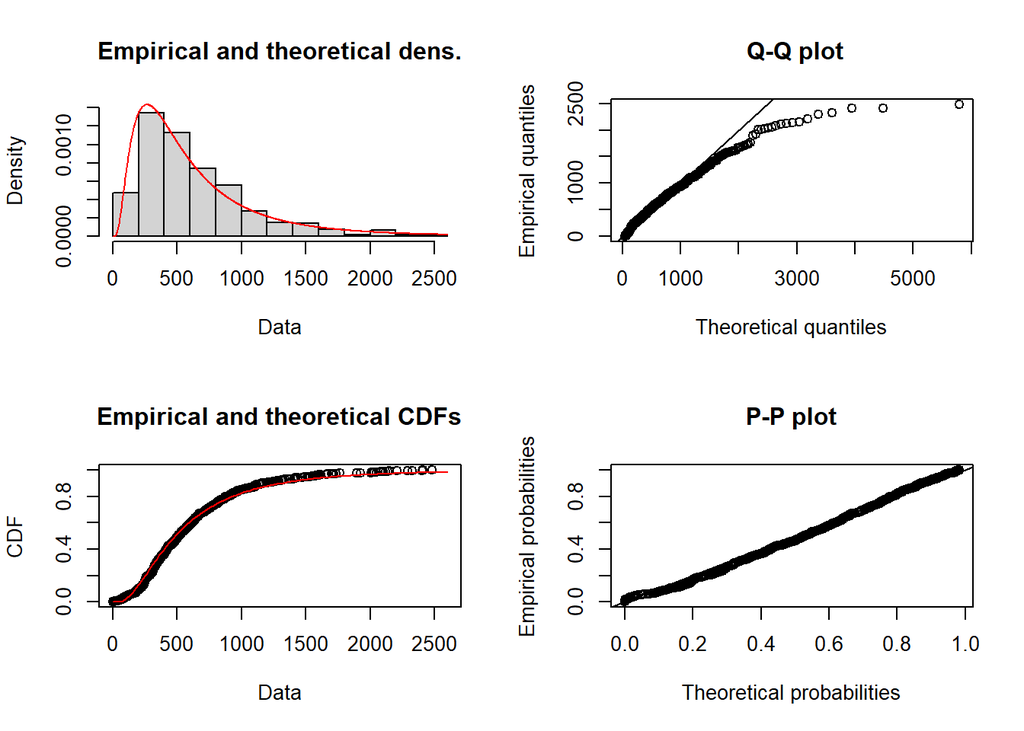

```
## Fitting of the distribution ' gamma ' by matching moments
## Parameters :
##         estimate
## shape 2.05904565
## rate  0.00331395
## Loglikelihood:  -5389.957   AIC:  10783.91   BIC:  10793.12
```

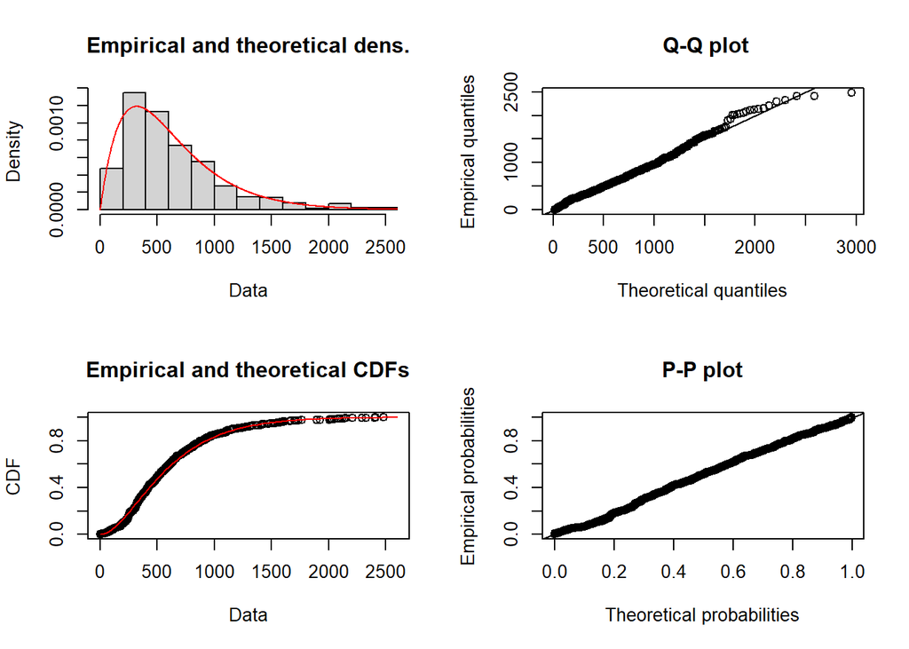

##### **Cortisol**

##### *Standard Inclusion Criteria*

Note: log-normal fits best but there are a few outliers, one of which is quite extreme. Plots excluded.

##### *Z-Score Outliers Removed*

Note: Gamma fits best, although I would like to consider removing between 1 and 5 outliers to improve the Q-Q plot fit.

```
## Fitting of the distribution ' lnorm ' by maximum likelihood
## Parameters :
##           estimate Std. Error
## meanlog 10.5565025 0.03662426
## sdlog    0.8502826 0.02589710
## Loglikelihood:  -6367.344   AIC:  12738.69   BIC:  12747.27
## Correlation matrix:
##         meanlog sdlog
## meanlog       1     0
## sdlog         0     1
```

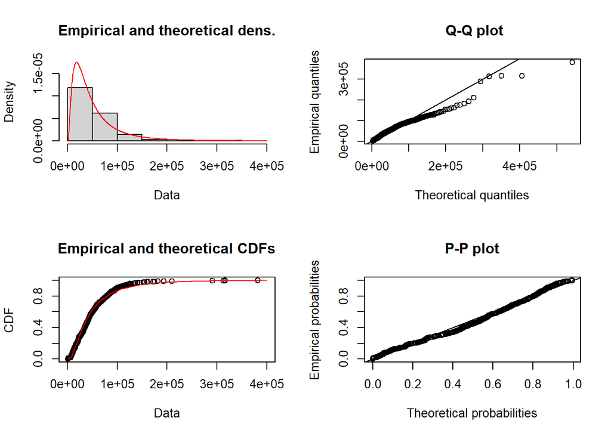

```
## Fitting of the distribution ' gamma ' by matching moments
## Parameters :
##           estimate
## shape 1.422273e+00
## rate  2.703472e-05
## Loglikelihood:  -6362.27   AIC:  12728.54   BIC:  12737.12
```

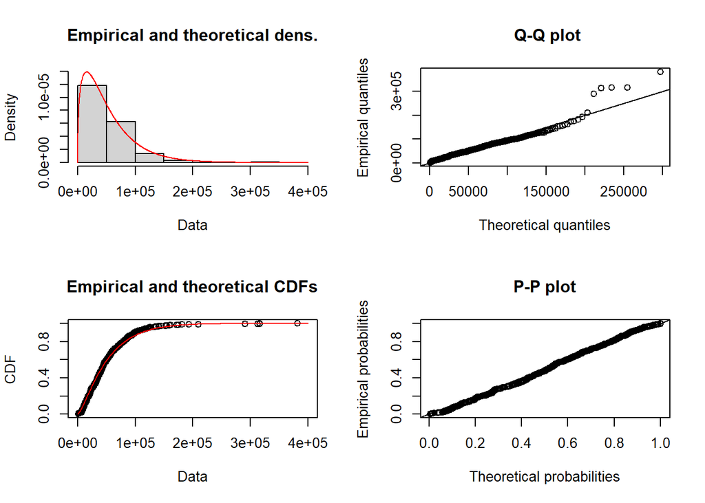

##### *Z-Score Outliers and 1 Remaining Point Removed*

Note: So the largest outlier was a cortisol value of at least 300,000. I removed it and the gamma plot came out best (see below). When I removed the next largest outlier (cortisol < 250,000), all plots looked great, so I will further filter cortisol to all values below 250,000. AIC and BIC values also dropped substantially.

```
## Fitting of the distribution ' gamma ' by matching moments
## Parameters :
##           estimate
## shape 1.8665157270
## rate  0.0000369444
## Loglikelihood:  -6276.834   AIC:  12557.67   BIC:  12566.23
```

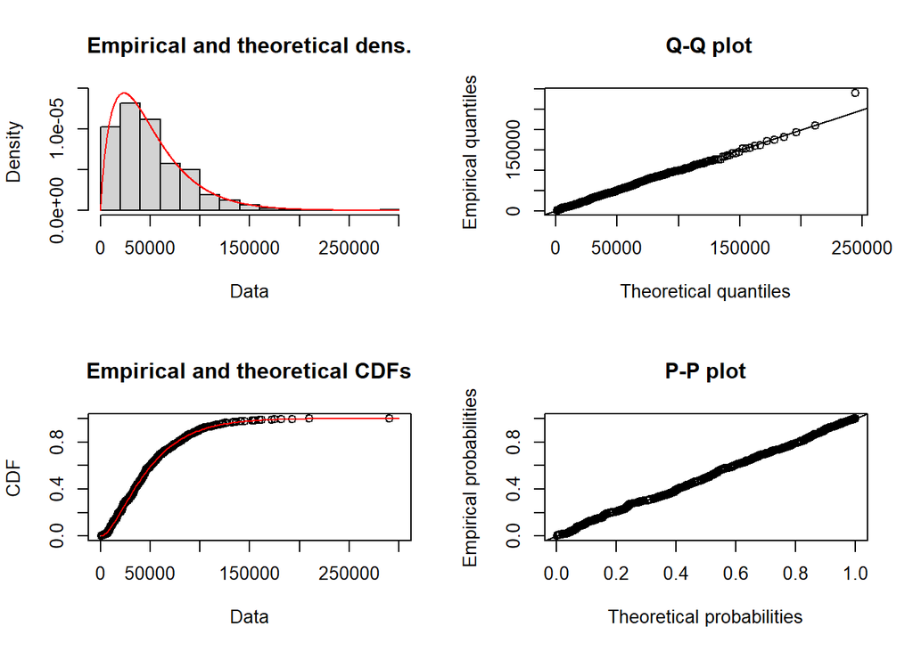

```
## Fitting of the distribution ' gamma ' by matching moments
## Parameters :
##           estimate
## shape 1.986525e+00
## rate  3.967244e-05
## Loglikelihood:  -6258.166   AIC:  12520.33   BIC:  12528.89
```

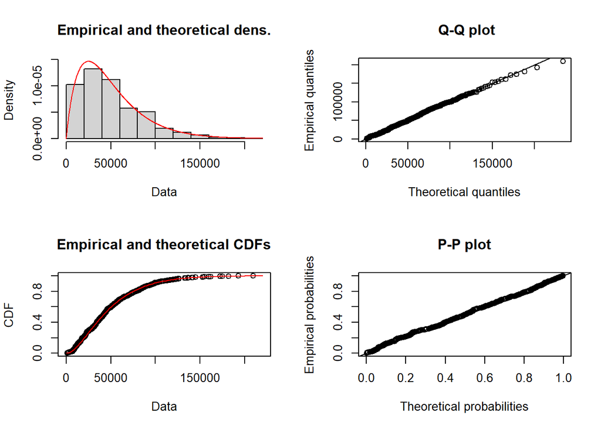

##### **ELBM**

##### *Standard Inclusion Criteria*

Note: Values must be positive to fit the lnorm, gamma, or exp distributions. Plots excluded.

```
## Fitting of the distribution ' norm ' by maximum likelihood
## Parameters :
##         estimate  Std. Error
## mean -0.02503602 0.013275643
## sd    0.33532498 0.009386922
## Loglikelihood:  -208.1688   AIC:  420.3376   BIC:  429.2543
## Correlation matrix:
##      mean sd
## mean    1  0
## sd      0  1
```

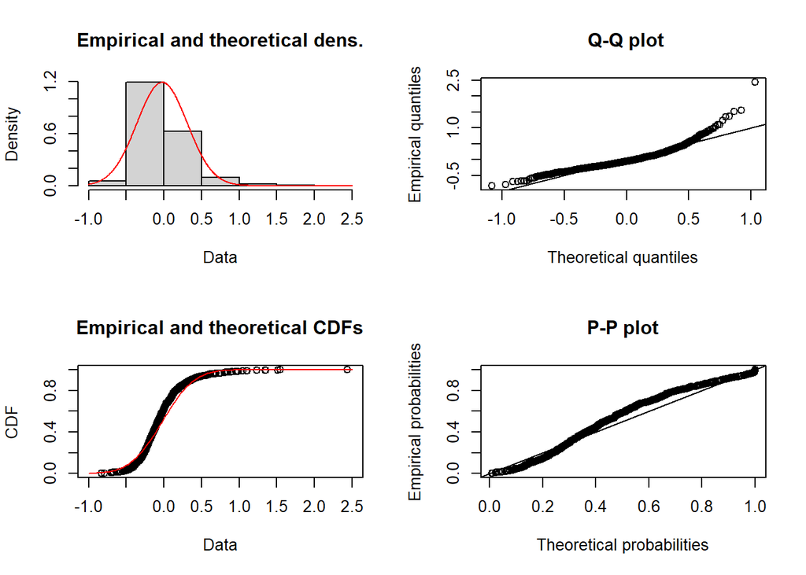

##### *Z-Score Outliers Removed*

Note: When looking at the distribution without outliers, the normal distribution seems to fit decently well and is much improved compared to the normal distribution with the outliers kept in. I will fit with the normal distribution.

```
## Fitting of the distribution ' norm ' by maximum likelihood
## Parameters :
##         estimate  Std. Error
## mean -0.04716648 0.011318374
## sd    0.28363764 0.008002851
## Loglikelihood:  -99.77713   AIC:  203.5543   BIC:  212.4393
## Correlation matrix:
##      mean sd
## mean    1  0
## sd      0  1
```

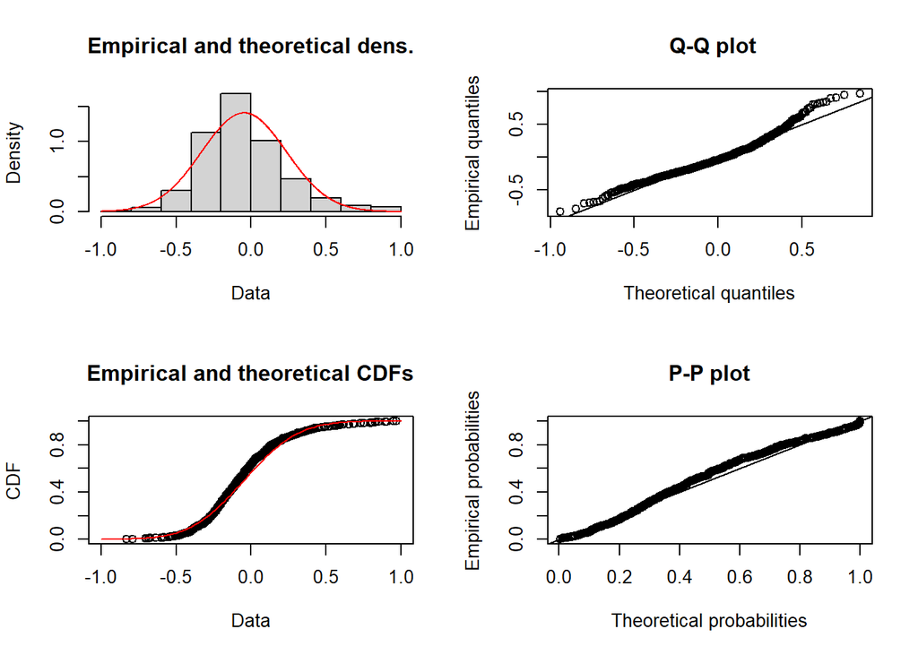